# Naive Bayes

AmrutaD

10/24/2019

Problem :-

Predicting flight delays can be useful to a variety of organizations. Here, we look at five predictors. The outcome of interest is whether or not the flight is delayed (delayed here means arrived more than 15 minutes late). Our data consist of all flights from the Washington, DC area into the New York City area during January 2004. A record is a particular flight. The percentage of delayed flights among these 2201 flights is 19.5%. The data were obtained from the Bureau of Transportation Statistics (available on the web at www.transtats.bts.gov). The goal is to accurately predict whether or not a new flight (not in this dataset), will be delayed. The outcome variable is whether the flight was delayed, and thus it has two classes (1 = delayed and 0 = on time).

Solution :-

- Using Library and reading the data :-

```r
library(ISLR)
library(caret)
library(dummies)
library(gmodels)
library(pROC)
library(e1071)

Flight_Delay <- read.csv("FlightDelays.csv")
```

Q2) Run the Naive Bayes model to predict whether the flight is delayed or not. Use only categorical variables for the predictor variables. Note that Week and Time variables need to recoded as factors.

- Factorising the Day of the Month and Week column :-

```r
Flight_Delay$DAY_OF_MONTH <- factor(Flight_Delay$DAY_OF_MONTH)
Flight_Delay$DAY_WEEK <- factor(Flight_Delay$DAY_WEEK, levels = c(1,2,3,4,5,6,7), labels = c("Monday", "Tuesday", "Wednesday", "Thursday", "Friday", "Saturday", "Sunday"))

Flight_Delay$CRS_DEP_TIME <- factor(round(Flight_Delay$CRS_DEP_TIME/100),labels = c("6-7 AM Slot","7-8 AM Slot","8-9 AM Slot", "9-10 AM Slot", "10-11 AM Slot", "11-12 PM Slot", "12-1 PM Slot", "1-2 PM Slot", "2-3 PM Slot", "3-4 PM Slot", "4-5 PM Slot", "5-6 PM Slot", "6-7 PM Slot", "7-8 PM Slot", "8-9 PM Slot", "9-10 PM Slot"))

Flight_Delay <- Flight_Delay[, c(1,2,4,8,10,13)]
head(Flight_Delay)
```

```
##    CRS_DEP_TIME CARRIER DEST ORIGIN DAY_WEEK Flight.Status
## 1   3-4 PM Slot      OH  JFK    BWI Thursday        ontime
## 2   4-5 PM Slot      DH  JFK    DCA Thursday        ontime
## 3  12-1 PM Slot      DH  LGA    IAD Thursday        ontime
## 4   5-6 PM Slot      DH  LGA    IAD Thursday        ontime
## 5 10-11 AM Slot      DH  LGA    IAD Thursday        ontime
## 6   8-9 AM Slot      DH  JFK    IAD Thursday        ontime
```

Q1) Divide the data into 60% training and 40% validation.

- Dividing the data as training and validation data :-

```r
set.seed(10)
Train_Data_Index <- createDataPartition(Flight_Delay$CARRIER, p= 0.6, list = FALSE)

Train_Data <-  Flight_Delay[Train_Data_Index,]
Validation_Data <-  Flight_Delay[-Train_Data_Index,]
```

Q2) Run the Naive Bayes model to predict whether the flight is delayed or not.

- Naive Bayes Model :-

```r
NB <- naiveBayes(Flight.Status~DAY_WEEK+CRS_DEP_TIME+ORIGIN+DEST+CARRIER, data=Train_Data)
NB
```

```
##
## Naive Bayes Classifier for Discrete Predictors
##
## Call:
## naiveBayes.default(x = X, y = Y, laplace = laplace)
##
## A-priori probabilities:
## Y
##   delayed    ontime
## 0.1980348 0.8019652
##
## Conditional probabilities:
##          DAY_WEEK
## Y             Monday    Tuesday  Wednesday   Thursday     Friday
##   delayed 0.18320611 0.14122137 0.12213740 0.14885496 0.19083969
##   ontime  0.12818096 0.14043355 0.13666352 0.16870877 0.18284637
##          DAY_WEEK
## Y           Saturday     Sunday
##   delayed 0.05343511 0.16030534
##   ontime  0.12818096 0.11498586
##
##          CRS_DEP_TIME
## Y         6-7 AM Slot 7-8 AM Slot 8-9 AM Slot 9-10 AM Slot 10-11 AM Slot
##   delayed  0.04580153  0.05343511  0.06106870   0.03053435    0.01526718
##   ontime   0.06032045  0.05749293  0.07445806   0.05466541    0.05278040
##          CRS_DEP_TIME
## Y         11-12 PM Slot 12-1 PM Slot 1-2 PM Slot 2-3 PM Slot 3-4 PM Slot
##   delayed    0.01526718   0.05343511  0.03816794  0.04198473  0.18702290
##   ontime     0.02921772   0.06786051  0.06314797  0.06032045  0.11215834
##          CRS_DEP_TIME
## Y         4-5 PM Slot 5-6 PM Slot 6-7 PM Slot 7-8 PM Slot 8-9 PM Slot
##   delayed  0.08015267  0.14503817  0.02671756  0.10305344  0.02671756
##   ontime   0.08765316  0.09802074  0.04335533  0.04806786  0.02639020
##          CRS_DEP_TIME
## Y         9-10 PM Slot
##   delayed   0.07633588
##   ontime    0.06409048
##
##          ORIGIN
## Y                BWI        DCA        IAD
##   delayed 0.08015267 0.50763359 0.41221374
##   ontime  0.06314797 0.64561734 0.29123468
##
##          DEST
## Y               EWR       JFK       LGA
##   delayed 0.3664122 0.1832061 0.4503817
##   ontime  0.2902922 0.1705938 0.5391140
##
##          CARRIER
## Y                  CO          DH          DL          MQ          OH
##   delayed 0.049618321 0.328244275 0.106870229 0.187022901 0.007633588
##   ontime  0.041470311 0.230914232 0.193213949 0.120640905 0.015080113
##          CARRIER
## Y                  RU          UA          US
##   delayed 0.217557252 0.011450382 0.091603053
##   ontime  0.177191329 0.015080113 0.206409048
```

Q3) Output both a counts table and a proportion table outlining how many and what proportion of flights were delayed and on-time at each of the three airports.

- Proportion at which flights were delayed or on-time at three airports, displayed in Proportion table :-

```r
Flight_Delay_Status<- table(Train_Data$Flight.Status, Train_Data$DEST)
Flight_Delay_Status
```

```
##
##           EWR JFK LGA
##   delayed  96  48 118
##   ontime  308 181 572
```

```r
prop.table(Flight_Delay_Status)
```

```
##
##                  EWR        JFK        LGA
##   delayed 0.07256236 0.03628118 0.08919123
##   ontime  0.23280423 0.13681028 0.43235072
```

Q4) Output the confusion matrix and ROC for the validation data.

- Confusion Matrix :-

```r
Validation_Label <- predict(NB, Validation_Data)
CrossTable(x = Validation_Data$Flight.Status, y = Validation_Label, prop.chisq = FALSE)
```

```
##
##
##    Cell Contents
## |-------------------------|
## |                       N |
## |           N / Row Total |
## |           N / Col Total |
## |         N / Table Total |
## |-------------------------|
##
##
## Total Observations in Table:  878
##
##
##                               | Validation_Label
## Validation_Data$Flight.Status |   delayed |    ontime | Row Total |
## ------------------------------|-----------|-----------|-----------|
##                       delayed |        14 |       152 |       166 |
##                               |     0.084 |     0.916 |     0.189 |
##                               |     0.400 |     0.180 |           |
##                               |     0.016 |     0.173 |           |
## ------------------------------|-----------|-----------|-----------|
##                        ontime |        21 |       691 |       712 |
##                               |     0.029 |     0.971 |     0.811 |
##                               |     0.600 |     0.820 |           |
##                               |     0.024 |     0.787 |           |
## ------------------------------|-----------|-----------|-----------|
##                  Column Total |        35 |       843 |       878 |
##                               |     0.040 |     0.960 |           |
## ------------------------------|-----------|-----------|-----------|
##
##
```

```r
confusionMatrix(Validation_Label, Validation_Data$Flight.Status)
```

```
## Confusion Matrix and Statistics
##
##           Reference
## Prediction delayed ontime
##    delayed      14     21
##    ontime      152    691
##
##                Accuracy : 0.803
##                  95% CI : (0.7751, 0.8288)
##     No Information Rate : 0.8109
##     P-Value [Acc > NIR] : 0.7427
##
##                   Kappa : 0.0786
##
##  Mcnemar's Test P-Value : <2e-16
##
##             Sensitivity : 0.08434
##             Specificity : 0.97051
##          Pos Pred Value : 0.40000
##          Neg Pred Value : 0.81969
##              Prevalence : 0.18907
##          Detection Rate : 0.01595
##    Detection Prevalence : 0.03986
##       Balanced Accuracy : 0.52742
##
##        'Positive' Class : delayed
##
```

- ROC :-

```r
Validation_Label_Raw <- predict(NB, Validation_Data, type = "raw")
head(Validation_Label_Raw)
```

```
##        delayed    ontime
## [1,] 0.1929916 0.8070084
## [2,] 0.2238243 0.7761757
## [3,] 0.3514404 0.6485596
## [4,] 0.2785612 0.7214388
## [5,] 0.3009396 0.6990604
## [6,] 0.3037118 0.6962882
```

```r
roc(Validation_Data$Flight.Status, Validation_Label_Raw[,2])
```

```
##
## Call:
## roc.default(response = Validation_Data$Flight.Status, predictor = Validation_Label_Raw[,     2])
##
## Data: Validation_Label_Raw[, 2] in 166 controls (Validation_Data$Flight.Status delayed) < 712 cases (Validation_Data$Flight.Status ontime).
## Area under the curve: 0.6786
```

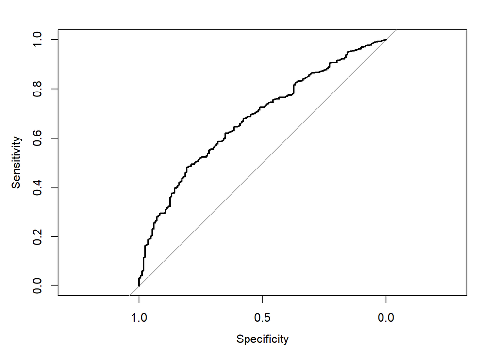

```r
plot.roc(Validation_Data$Flight.Status, Validation_Label_Raw[,2])
```